# Microbial Mapping - Geographic Maps and Data

# Document Summary

This code is for importing geographic data, extracting data based on GPS location, and plotting sampling points onto various GIS layers.

## Load libraries:

Libraries are separated into general utility and spatial. There are several large spatial libraries required for this analysis.

[output not shown]

## Set up ggplot

Set some custom scales and functions for ggplot

```r
theme_set(theme_bw())
# discrete color palette
pal_d = "Dark2"
scale_colour_discrete <-  function(palname=pal_d, ...){
  scale_colour_brewer(palette=palname, ...)
}
scale_fill_discrete <-  function(palname=pal_d, ...){
    scale_fill_brewer(palette=palname, ...)
}
# continuous color palette
pal_c = "C"
uniform_gradient_color <- function(palname = pal_c,...){
  scale_color_viridis_c(option = palname, ...)
}

uniform_gradient_fill <- function(palname = pal_c,...){
  scale_fill_viridis_c(option = palname, ...)
}
```

## Read in the data

Read in the data as a data.table instead of data.frame

```r
# Read in raw sample metadata
meta <- fread("../data/raw/sample/unique_waimea_hiseq_samples_emp.tsv")
# drop samples with no geographic information (i.e. lab samples)
meta <- na.omit(meta, cols = c("latitude_deg","longitude_deg"))
```

# Spatial Definitions

Define spatial attributes of the data. Bounding box is important for subsetting larger spatial datasets to the correct area. Spatial data will only match up if all data is projected according to the same model.

## Define bounding box

All spatial points dataframes will have a bounding box attribute. Define the bounding box based on geographic range of sampling points. Format bounding box for use with multiple packages.

```r
# Check geographic range of sampling points
limits <- c(
               min(meta$longitude_deg),
               min(meta$latitude_deg),
               max(meta$longitude_deg),
               max(meta$latitude_deg)
               )
# Define bounding box with a cushion around sampling points
bbox <- list(
  p1 = list(long = limits[1] - 0.015, lat = limits[2] - 0.002) ,
  p2 = list(long = limits[3] + 0.015, lat = limits[4] + 0.002)
)
# add a reformatted version of this box for use with ggmap
bbox$ggmap <- unlist(bbox[1:2])
names(bbox$ggmap) <- c("left","bottom","right","top")
# create an emtpy spatial polygon template of the bounding box for pulling elevation data
bbox_extent <- polygon_from_extent(raster::extent(bbox$p1$long, bbox$p2$long, bbox$p1$lat, bbox$p2$lat),
                               proj4string = "+proj=longlat +ellps=GRS80 +datum=WGS84 +no_defs")
```

# Sat Images

The benefit of ggmap is integration with ggplot2 and all the features that go along with that. Mainly, I like the nice graphics, especially for plotting points/density/etc. type of data.

The restriction that ggmap imposes is a strict requirement that all plots conform to a mercator projection instead of cartesian. This becomes a bit of a hassle once you import rasters, which are generally cartesian by default. The default settings are nice, but the package is not very flexible.

It looks like the package sf is more adaptable and widely used. I will try to transition all mapping to sf package instead of ggmaps.

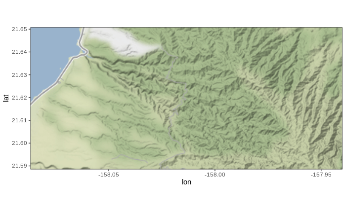

```r
# pull base map images
base_data <- get_map(location = bbox$ggmap, maptype = c("terrain"), zoom = 12)
# plot base map
base_map  <- ggmap(base_data)
base_map
```

```r
NA
```

# Rasters

Raster data need to be cropped to the same extent as our map.

## Elevation

Elevation data is important for our maps, where sites are staggered along an elevational gradient. These data will also come into play for the 3D mapping portion of this project.

Notes: You can plot rasters onto ggplot maps (e.g. ggmaps), but a couple of issues arise. 1) ggmaps sets the coordinate system to mercator, which does not allow caretesian rasters to be plotted on top, so you can’t use straight geom_raster. You can get around this by forcing carteisian coordinates( coord_carteisan), but this is technically inacurate.

2. You can plot your geom_raster as a polygon instead, but this is slow and kind of convoluted.
3. You can normalize your raster to values between 0:1 (mat/max(mat)) then use inset_raster from ggmap, but there’s no way to change the transparency (alpha)

### Plot Elevation

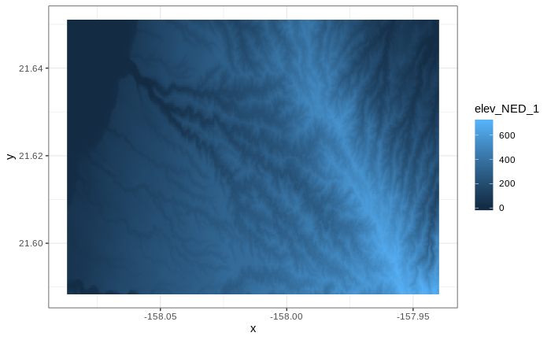

### Extract Elevation Data

```r
meta$elevation <-  raster::extract(x = elev_ras,
                        y = meta[, c("longitude_deg","latitude_deg")],
                        df = TRUE)[[2]]
```

## Rainfall

Rainfall data closely mirrors elevation. Precipitation is calculated as yearly average, and can befound at rainfall atlas of hawaii and evapotranspiration hawaii http://rainfall.geography.hawaii.edu/rainfall.html

Note: Monique Chyba in the math department was working on taking fine grain rainfall data and generating a rainfall dataset that accounts for variance better than ‘mean’ rainfall.

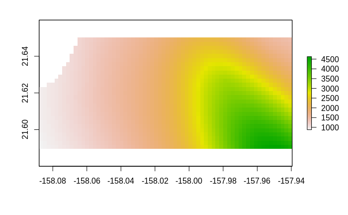

```r
# rasters are yearly averages, and can be
# found at rainfall atlas of hawaii and evapotranspiration hawaii
# http://rainfall.geography.hawaii.edu/rainfall.html
#Extract data from rasters using sampling coordinates
set_proj <- "+proj=longlat +datum=WGS84 +no_defs +ellps=WGS84"
# read annual rainfall txt file as raster
rain_ras <- raster("../data/raw/spatial/rfgrid_mm_oahu_ann.txt", crs = set_proj)
# crop to correct bbox
rain_ras <- crop(rain_ras, bbox_extent)
plot(rain_ras)
```

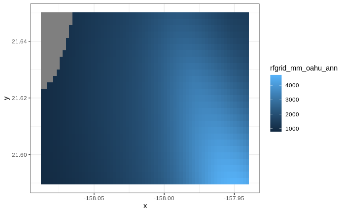

```r
# and convert raster to data table and matrix for making other kinds of plots
rain_dt  <- raster::as.data.frame(rain_ras, xy=T) %>% as.data.table()
rain_mat <- as.matrix(rain_ras) %>% t()
# plot elevation data table in ggplot
rain_map <- ggplot() +
            geom_raster(data= rain_dt, mapping =aes(x = x, y = y, fill = rfgrid_mm_oahu_ann))
rain_map
```

### Extract Rainfall Data

Pull out rainfall data from raster and store as column ‘rainfall’ in the metadata

```r
meta$rainfall <-  raster::extract(x = rain_ras,
                        y = meta[ , c("longitude_deg","latitude_deg")],
                        df = TRUE)[[2]]
```

# Points

Points being plotted onto the map will be placed based on latitude and longitude. Each sampling point has specific lat/long and associated environmental metadata. Many samples were collected at each point.

Generally, we will be pulling out site specific data (rainfall, elevation, lat/long) and aggregating sample related data for each site (e.g. number of samples, abundance of taxon, etc).

## Plot Points - XY

Start by grouping data by spatial points. Plot points onto different basemaps using ggplot. Do the points end up in the right place? They should. Note: Riverine and terrestrial plots have the same gps reference point. They overlap and cancel each other out.

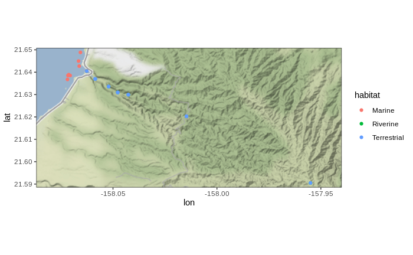

## Plot Points and Lines

Instead of plotting riverine sites as a point, they should be plotted as a line 100m long. This is a more accurate representation of the data collection.

Ideally, these lines are 100m crops of the actual stream path To do this, read in the oahu streams layer from DAR.

DAR stream layers can be downloaded using a REST API: infromation: https://geoportal.hawaii.gov/datasets/streams/geoservice?page=6

query url: https://geodata.hawaii.gov/arcgis/rest/services/FreshWater/MapServer/1/query?where=stream_nam%20%3D%20'WAIMEA%20R’&outFields=*&outSR=4326&f=json

However, I’m not really sure how to convert that data into a shapefile. Luckily, I already have the shapefile.

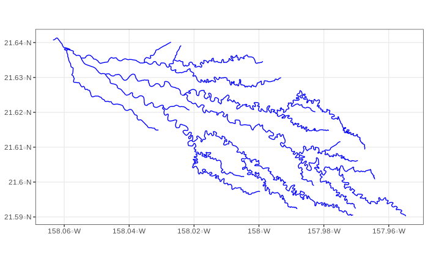

## Plot Points and Lines

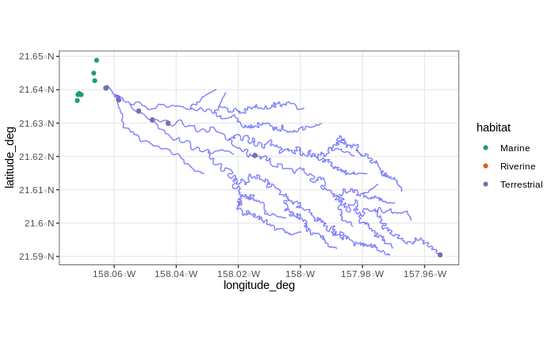

```r
# Plot on plain background
ggplot() +
  geom_sf(data = waimea_river, color = alpha("blue",0.5)) +
  geom_point(aes(x = longitude_deg, y = latitude_deg, color = habitat), data = point_data)
```

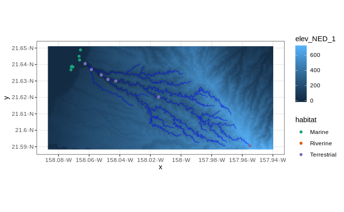

```r
# Plot on raster background
ggplot() +
  geom_raster(data= elev_dt, mapping =aes(x = x, y = y, fill = elev_NED_1))+
  geom_sf(data = waimea_river, color = alpha("blue",0.5)) +
  geom_point(aes(x = longitude_deg, y = latitude_deg, color = habitat), data = point_data)
```

```r
NA
```

# 3D Rayshading

Pulling code from ST_rayshading. Goals: - Wrap up everything in modular functions - Overlay raster - Overlay xy points

For the Rayshader to work, everything needs to match up exactly. Since the elevation raster forms the basis for the 3d map, overlayed images need to match the raster exactly. To help out, I’m pulling heavily from this tutorial https://wcmbishop.github.io/rayshader-demo/

Overlaying a raster on top of rayshader map is actually pretty doable with raster::image function. Trying to do this with any other output from ‘plot’ or ‘ggplot’ was basically impossible, however. There’s no good way to entirely get rid of margins and have the image perfectly match the required size of the underlying elevation raster. However, as long as the visualization you want to overlay is a raster, you can just export the raster to a png file.

```r
# use this fuction to define image size
define_image_size <- function(bbox, major_dim = 400) {

  # calculate aspect ration (width/height) from lat/long bounding box
  aspect_ratio <- abs((bbox$p1$long - bbox$p2$long) / (bbox$p1$lat - bbox$p2$lat))

  # define dimensions
  img_width <- ifelse(aspect_ratio > 1, major_dim, major_dim*aspect_ratio) %>% round()
  img_height <- ifelse(aspect_ratio < 1, major_dim, major_dim/aspect_ratio) %>% round()

  size_str <- paste(img_width, img_height, sep = ",")

  list(height = img_height, width = img_width, size = size_str)}
# calculate image dimensions based on size of elevation raster
img_size <- define_image_size(bbox = bbox, major_dim = max(dim(elev_ras)))
# now export the raster as a png with the same dimensions as the raster
# test 1 is just the same elevation raster
png("../data/processed/interim/test1.png", width = img_size$width, height = img_size$height)
par(mar = c(0,0,0,0))
raster::image(elev_ras, axes = F, col = rev(terrain.colors(1000)))
dev.off()
```

## Calculate rayshades

```r
raymat <- ray_shade(elev_mat, zscale = 30, lambert = TRUE)
```

```
Raytracing [-----------------------------------------------------------------------------------------------------------------------------------------------------------------] ETA:  0s
Raytracing [=================================================================================================================================================================] ETA:  0s
```

## 2D Plots - Raster Overlay

```
Calculating Surface Normal [=------------------------------------------------------------------------------------------------------------------------------------------------] ETA:  0s
Calculating Surface Normal [=================================================================================================================================================] ETA:  0s
```

```
Overlay doesn't match dimension of hillshade--resizing to match
```

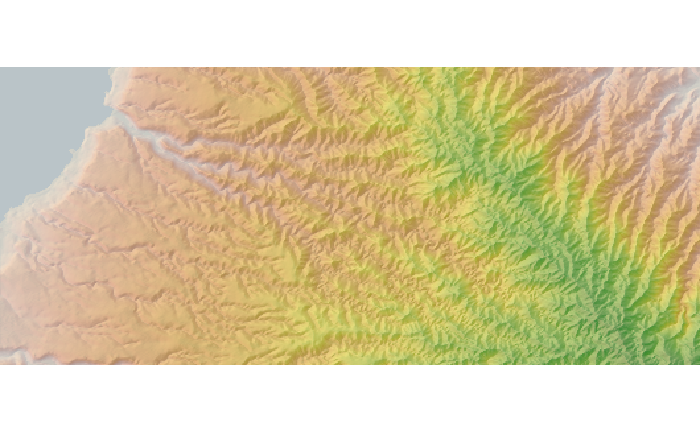

```r
# plot 2D
elev_mat %>%
  sphere_shade(texture = "imhof4") %>%
  add_water(watermap, color = "imhof4") %>%
  add_shadow(raymat, max_darken = 0.5) %>%
  add_shadow(ambmat, max_darken = 0.5) %>%
  add_overlay(elev_overlay, alphalayer = 0.5) %>%
  plot_map()
```

## 3D Plot - No Overlay

```r
# clear plot
rgl::clear3d()
```

```
font family "sans" not found, using "bitmap"
```

```r
# plot that 3d map!
elev_mat %>%
  sphere_shade(texture = "imhof1") %>%
  add_water(watermap, color = "imhof1") %>%
  add_shadow(raymat, max_darken = 0.5) %>%
  add_shadow(ambmat, 0) %>%
  plot_3d(elev_mat, zscale = zscale, windowsize = c(1200, 1000),
          water = TRUE, wateralpha = 0.5,
          theta = -120, phi = 20, zoom = 0.65, fov = 0)
```

```
Calculating Surface Normal [=------------------------------------------------------------------------------------------------------------------------------------------------] ETA:  0s
Calculating Surface Normal [=================================================================================================================================================] ETA:  0s
```

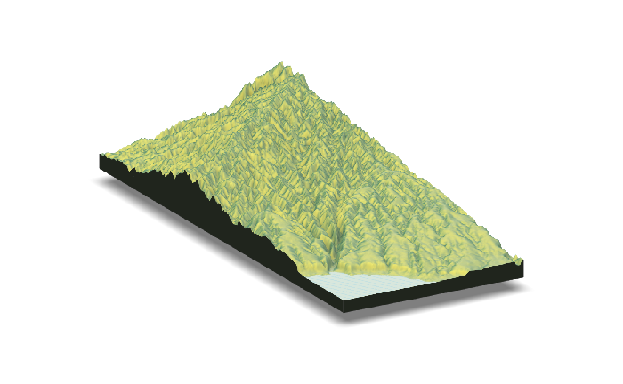

```r
render_snapshot()
```

## 3D Plot - Raster Overlay

```r
# Plot 3D - elevation
# clear plot
rgl::clear3d()
```

```
font family "sans" not found, using "bitmap"
```

```r
# plot that 3d map!
elev_mat %>%
  sphere_shade(texture = "imhof1") %>%
  add_water(watermap, color = "imhof1") %>%
  add_shadow(raymat, max_darken = 0.5) %>%
  add_shadow(ambmat, 0) %>%
  add_overlay(elev_overlay, alphalayer = 0.5) %>%
  plot_3d(elev_mat, zscale = zscale, windowsize = c(1200, 1000),
          water = TRUE, wateralpha = 0.5,
          theta = -120, phi = 20, zoom = 0.65, fov = 0)
```

```
Calculating Surface Normal [=------------------------------------------------------------------------------------------------------------------------------------------------] ETA:  0s
Calculating Surface Normal [=================================================================================================================================================] ETA:  0s
```

```
Overlay doesn't match dimension of hillshade--resizing to match
```

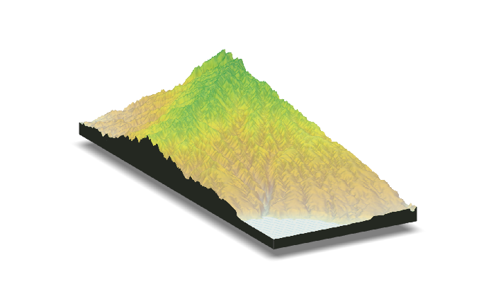

```r
render_snapshot()
```

# Adding points - Define Functions

```r
# pull out sample points and remove NA values
samps <- point_data
# define function to assign viridis colors to each value and store in dataframe
map_viridis <- function(column = "shore_dist", dataframe) {
  # returns the data frame, with new column plot_color
  # column = "shore_dist"
  # dataframe = samps
  vec <- dataframe[[column]]
  # warn if NAs exist in data
  if(any(is.na(vec))){
    warning("NAs present in vector, dropping NA")
  }
  vec <- vec[!is.na(vec)]

  # expand to allow for decimal precision
  vector_expanded <-round(vec, 1) * 10
  vector_exp_range <- max(vector_expanded) - min(vector_expanded)

  # get vector of colour values for all possible decimals between min and max value
  colour_vector <- viridis(vector_exp_range + 1)

  # match each number in vec with the appropriate color
  picked_colors <-sapply(vec, FUN = function(x) colour_vector[x * 10 - min(vector_expanded) +1])

  # return vector and color as dataframe
  result <-data.frame(vec,  picked_colors)
  colnames(result) <- c(column, "plot_color")
  return(left_join(dataframe, result))
}
# get viridis colors for shore_dist at each point
samps <- map_viridis(column = "elevation", dataframe = samps)
# Define function to add points to rayshader plot
# this function came from library geoviz
# "fixed" add_gps by cutting out all the line related items, and having it plot points exclusively
# also just made it so params get written out and I can rgl:: spheres3d separately
custom_add_points <- function (raster_input, lat, long, alt, zscale,
          colour = "red", alpha = 0.8,
          raise_agl = 0, point_size = 20, rad = 2) {
  # convert lat long to rayshader x/y
  coords <- latlong_to_rayshader_coords(raster_input, lat,
                                        long)
  distances_x <- coords$x
  distances_y <- coords$y

  # create spatial points dataframe from lat long and match to elevation raster projection
    sp_gps <- sp::SpatialPoints(cbind(long, lat), proj4string = sp::CRS("+init=epsg:4326"))
    sp_gps <- sp::spTransform(sp_gps, sp::CRS(as.character(raster::crs(raster_input))))

  # extract raster data at gps points to get base elevation
    gps_ground_line <- raster::extract(raster_input, sp_gps)

  # raise points by defined amount
    track_altitude <- gps_ground_line + raise_agl

  # return list of points data
    return(list("x" = distances_x, "y" = track_altitude/zscale, "z" = -distances_y, "col" = colour, "alpha" = alpha, "size" = point_size, "radius" = rad))
}
sites_spheres <- custom_add_points( elev_ras,
                                        samps$latitude_deg,
                                        samps$longitude_deg,
                                        raise_agl = 10,
                                        zscale = zscale,
                                        colour = samps$plot_color,
                                        point_size = 5,
                                        rad = 2)
```

## Adding Points - 3D Plot

```r
## still version for checking image quality
# clear plot
rgl::clear3d()
# generate 3D map with overlay
elev_mat %>%
  sphere_shade(texture = "imhof1") %>%
  add_water(watermap, color = "desert") %>%
  add_shadow(raymat, max_darken = 0.5) %>%
  add_shadow(ambmat, 0) %>%
  add_overlay(elev_overlay, alphalayer = 0.5) %>%
  rayshader::plot_3d(
    elev_mat,
    zscale = zscale,
    windowsize = c(1200, 1000),
    water = F,
    wateralpha = 0.2,
    theta = 237,
    phi = 25,
    zoom = 0.55,
    fov = 0,
    shadow = T
    )
```

```
Calculating Surface Normal [=------------------------------------------------------------------------------------------------------------------------------------------------] ETA:  0s
Calculating Surface Normal [=================================================================================================================================================] ETA:  0s
```

```
Overlay doesn't match dimension of hillshade--resizing to match
```

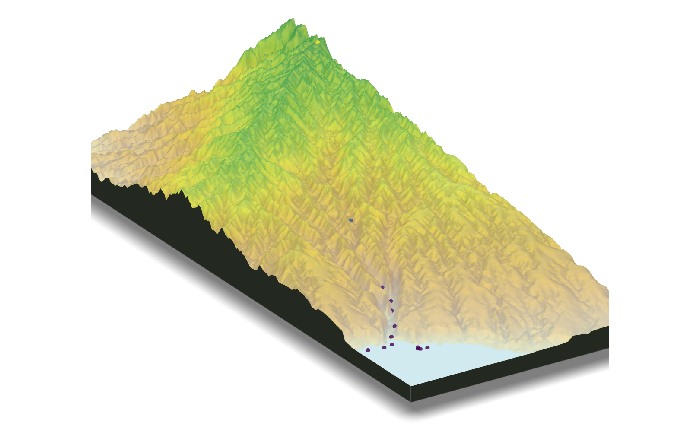

```r
# add points
rgl::points3d(sites_spheres$x, sites_spheres$y, sites_spheres$z,
                   color = sites_spheres$col, alpha = sites_spheres$alpha, size = sites_spheres$size)
render_snapshot()
```